# Non-Destructive Freshness Assessment in Fish Fillets via NIR Spectroscopy: Multivariate Optimization and K-value Classification Strategies

## **Classification Models**

Let $\{(x_i, y_i)\}_{i=1}^n$ be a training dataset, where $x_i \in \mathbb{R}^p$ denotes the vector of NIR wavelengths and $y_i \in \{0, 1\}$ the corresponding freshness label.

### 2.1 Naïve Bayes (NB)

Naïve Bayes applies Bayes’ theorem under the assumption of conditional independence between predictors given the class label:

$$\hat{y}(x) = \arg\max_{c} \; \log \pi_c
+ \sum_{j=1}^p \log p(x_j \mid y = c)$$

where $\pi_c$ is the prior probability of class $c$ and $p(x_j \mid y = c)$ is the class-conditional density of the $j$-th predictor, estimated via Gaussian kernel smoothing. Despite the strong independence assumption — rarely satisfied in NIR data due to high inter-wavelength correlation — Naïve Bayes often performs competitively in practice, particularly in small-sample settings.

### 2.2 Linear Discriminant Analysis (LDA)

LDA assumes multivariate normality within each class with a shared covariance matrix $\Sigma$:

$$x \mid y = c \sim \mathcal{N}(\mu_c,
\Sigma)$$

Classification is based on the linear discriminant score:

$$\delta_c(x) = x^\top \Sigma^{-1} \mu_c -
\frac{1}{2} \mu_c^\top \Sigma^{-1} \mu_c + \log \pi_c$$

When $p > n$, $\Sigma$ is singular and LDA is computed via singular value decomposition (SVD), projecting data onto the subspace of maximum class separation. LDA produces linear decision boundaries and is statistically efficient under its assumptions, making it a suitable baseline in small-sample, high-dimensional settings.

### 2.3 Quadratic Discriminant Analysis (QDA)

QDA relaxes the equal-covariance assumption of LDA, allowing class-specific covariance matrices $\Sigma_c$:

$$\delta_c(x) = -\frac{1}{2} \log
|\Sigma_c| - \frac{1}{2}(x - \mu_c)^\top \Sigma_c^{-1}(x - \mu_c) + \log
\pi_c$$

QDA produces quadratic decision boundaries and can capture heteroscedastic class structures, but requires sufficient within-class observations to estimate $\Sigma_c$ reliably. In high-dimensional settings with small samples, QDA is prone to rank deficiency and was therefore restricted to a maximum of two selected wavelengths.

### 2.4 k-Nearest Neighbours (k-NN)

Given a new observation $x$, the predicted class is determined by majority vote among the $k$ nearest training points $\mathcal{N}_k(x)$:

$$\hat{y}(x) = \arg\max_{c} \sum_{i \in
\mathcal{N}_k(x)} \mathbb{I}(y_i = c)$$

k-NN is a non-parametric, instance-based classifier that makes no distributional assumptions. Its bias-variance trade-off is governed by $k$, which was tuned jointly with the number of retained wavelengths via inner cross-validation. The optimal kernel weighting function was also selected during tuning.

### 2.5 Support Vector Machine (SVM)

SVM estimates a separating hyperplane by solving the regularised optimisation problem:

$$\min_{w,b,\xi} \; \frac{1}{2}\|w\|^2 +
C\sum_{i=1}^n \xi_i \quad \text{subject to} \quad y_i(w^\top x_i + b)
\geq 1 - \xi_i, \; \xi_i \geq 0$$

where $C > 0$ controls the margin-error trade-off and was tuned via inner cross-validation. A linear kernel was used, appropriate for high-dimensional settings where $p \gg n$. Predictors were standardised prior to fitting to ensure comparable feature scales.

### 2.6 Random Forest (RF)

Random Forest builds an ensemble of $B$ decision trees, each trained on a bootstrap sample of the data with a random subset of $m$ predictors considered at each split:

$$\hat{y}(x) = \arg\max_{c} \sum_{b=1}^B
\mathbb{I}(\hat{y}_b(x) = c)$$

RF is robust to overfitting through averaging, handles high-dimensional correlated predictors well, and provides variable importance measures via the mean decrease in node impurity. $B = 500$ trees were used in all experiments.

### 2.7 XGBoost

XGBoost fits an additive ensemble of $M$ regression trees by sequentially minimizing a regularized objective:

$$\mathcal{L} = \sum_{i=1}^n
\ell\!\left(y_i,\, \hat{y}_i^{(m-1)} + f_m(x_i)\right) +
\Omega(f_m)$$

where $\ell$ is the logistic loss for binary classification, $f_m$ is the $m$-th tree added at iteration $m$, and $\Omega(f_m)$ penalises tree complexity. The learning rate $\eta = 0.1$, maximum tree depth of 3, and subsampling-ratio of 0.8 were fixed across all experiments.

### 2.8 Comparative Summary

| Model | Decision boundary | Distributional assumptions | Notes |
| --- | --- | --- | --- |
| Naïve Bayes | — | Conditional independence | Robust with small $n$ |
| LDA | Linear | Multivariate normal, equal $\Sigma$ | SVD-based for $p > n$ |
| QDA | Quadratic | Multivariate normal, class-specific $\Sigma_c$ | Restricted to $\leq 2$ wavelengths |
| k-NN | Non-parametric | None | $k$ and kernel tuned via CV |
| SVM | Linear | None | $C$ tuned via CV, features scaled |
| Random Forest | Non-parametric | None | 500 trees, impurity importance |
| XGBoost | Non-parametric | None | $\eta = 0.1$, depth = 3 |

## **Comparative Analysis and Model Performance**

### 3.1 Classification Performance

Table 6 reports the balanced accuracy, AUC, sensitivity, and specificity for all classifier-feature selection combinations on both datasets. The figure summarises the best configuration per classifier.

Table 6: Model summaries

| dataset | learner | fs_method | acc | bacc | auc | sens | spec |
| --- | --- | --- | --- | --- | --- | --- | --- |
| IMP | RF_anova | anova | 0.673 | 0.560 | 0.529 | 0.853 | 0.267 |
| IMP | SVM_auc | auc | 0.612 | 0.534 | 0.439 | 0.735 | 0.333 |
| IMP | kNN_auc | auc | 0.653 | 0.508 | 0.565 | 0.882 | 0.133 |
| IMP | RF_auc | auc | 0.653 | 0.508 | 0.488 | 0.882 | 0.133 |
| IMP | XGBoost_anova | anova | 0.653 | 0.508 | 0.502 | 0.882 | 0.133 |
| IMP | kNN_anova | anova | 0.673 | 0.504 | 0.591 | 0.941 | 0.067 |
| IMP | NB_anova | anova | 0.592 | 0.501 | 0.539 | 0.735 | 0.267 |
| IMP | NB_mrmr | mrmr | 0.571 | 0.486 | 0.516 | 0.706 | 0.267 |
| IMP | kNN_mrmr | mrmr | 0.612 | 0.478 | 0.425 | 0.824 | 0.133 |
| IMP | XGBoost_auc | auc | 0.612 | 0.478 | 0.527 | 0.824 | 0.133 |
| IMP | XGBoost_mrmr | mrmr | 0.612 | 0.478 | 0.482 | 0.824 | 0.133 |
| IMP | QDA_anova | anova | 0.551 | 0.472 | 0.514 | 0.676 | 0.267 |
| IMP | LDA_anova | anova | 0.571 | 0.468 | 0.510 | 0.735 | 0.200 |
| IMP | SVM_mrmr | mrmr | 0.551 | 0.453 | 0.429 | 0.706 | 0.200 |
| IMP | RF_mrmr | mrmr | 0.551 | 0.453 | 0.510 | 0.706 | 0.200 |
| IMP | SVM_anova | anova | 0.551 | 0.434 | 0.459 | 0.735 | 0.133 |
| IMP | LDA_mrmr | mrmr | 0.531 | 0.420 | 0.573 | 0.706 | 0.133 |
| IMP | NB_auc | auc | 0.510 | 0.405 | 0.463 | 0.676 | 0.133 |
| IMP | QDA_mrmr | mrmr | 0.490 | 0.390 | 0.606 | 0.647 | 0.133 |
| IMP | LDA_auc | auc | 0.510 | 0.386 | 0.463 | 0.706 | 0.067 |
| IMP | QDA_auc | auc | 0.469 | 0.338 | 0.594 | 0.676 | 0.000 |
| REAL | NB_mrmr | mrmr | 0.700 | 0.667 | 0.718 | 0.545 | 0.789 |
| REAL | RF_mrmr | mrmr | 0.667 | 0.622 | 0.612 | 0.455 | 0.789 |
| REAL | XGBoost_auc | auc | 0.667 | 0.622 | 0.608 | 0.455 | 0.789 |
| REAL | NB_anova | anova | 0.633 | 0.615 | 0.584 | 0.545 | 0.684 |
| REAL | kNN_anova | anova | 0.633 | 0.615 | 0.531 | 0.545 | 0.684 |
| REAL | SVM_auc | auc | 0.533 | 0.612 | 0.603 | 0.909 | 0.316 |
| REAL | LDA_auc | auc | 0.600 | 0.608 | 0.617 | 0.636 | 0.579 |
| REAL | NB_auc | auc | 0.600 | 0.569 | 0.493 | 0.455 | 0.684 |
| REAL | kNN_auc | auc | 0.567 | 0.543 | 0.517 | 0.455 | 0.632 |
| REAL | RF_anova | anova | 0.567 | 0.543 | 0.541 | 0.455 | 0.632 |
| REAL | QDA_auc | auc | 0.533 | 0.536 | 0.416 | 0.545 | 0.526 |
| REAL | RF_auc | auc | 0.533 | 0.536 | 0.574 | 0.545 | 0.526 |
| REAL | LDA_mrmr | mrmr | 0.500 | 0.529 | 0.536 | 0.636 | 0.421 |
| REAL | SVM_mrmr | mrmr | 0.500 | 0.529 | 0.502 | 0.636 | 0.421 |
| REAL | QDA_anova | anova | 0.500 | 0.510 | 0.512 | 0.545 | 0.474 |
| REAL | QDA_mrmr | mrmr | 0.533 | 0.498 | 0.541 | 0.364 | 0.632 |
| REAL | XGBoost_mrmr | mrmr | 0.500 | 0.471 | 0.474 | 0.364 | 0.579 |
| REAL | kNN_mrmr | mrmr | 0.500 | 0.452 | 0.428 | 0.273 | 0.632 |
| REAL | XGBoost_anova | anova | 0.433 | 0.419 | 0.608 | 0.364 | 0.474 |
| REAL | SVM_anova | anova | 0.367 | 0.385 | 0.555 | 0.455 | 0.316 |
| REAL | LDA_anova | anova | 0.400 | 0.373 | 0.718 | 0.273 | 0.474 |

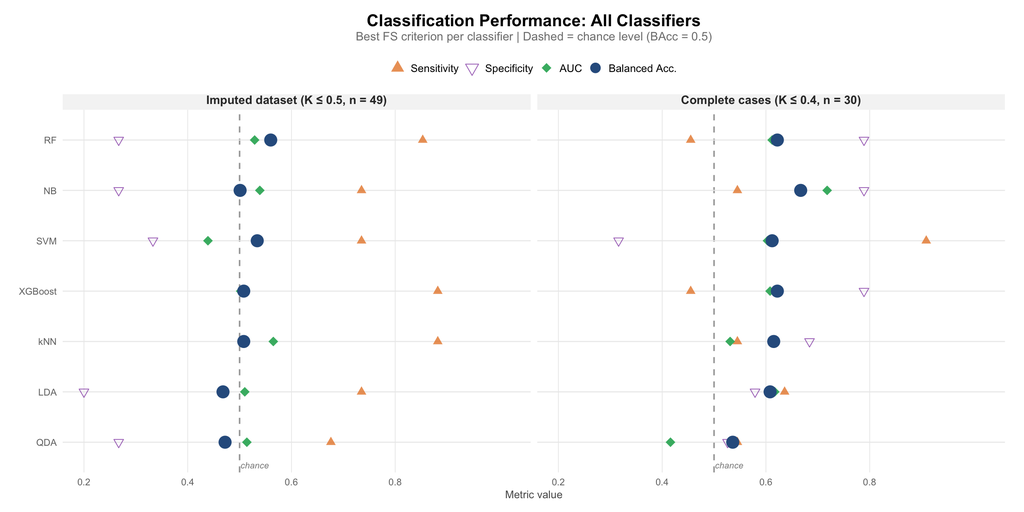

### 3.2 Sensitivity Analysis

Table 7: Sensitive analysis (imputed data)

| learner | metric | mean | sd | ci_low | ci_up |
| --- | --- | --- | --- | --- | --- |
| RF | acc | 0.616 | 0.051 | 0.584 | 0.648 |
| RF | bacc | 0.532 | 0.076 | 0.485 | 0.579 |
| RF | auc | 0.574 | 0.053 | 0.541 | 0.607 |
| RF | sens | 0.767 | 0.068 | 0.725 | 0.809 |
| RF | spec | 0.297 | 0.165 | 0.194 | 0.399 |
| SVM | acc | 0.635 | 0.065 | 0.594 | 0.675 |
| SVM | bacc | 0.566 | 0.062 | 0.527 | 0.605 |
| SVM | auc | 0.529 | 0.064 | 0.489 | 0.569 |
| SVM | sens | 0.760 | 0.081 | 0.709 | 0.810 |
| SVM | spec | 0.373 | 0.119 | 0.299 | 0.446 |
| kNN | acc | 0.629 | 0.049 | 0.598 | 0.659 |
| kNN | bacc | 0.518 | 0.069 | 0.475 | 0.560 |
| kNN | auc | 0.583 | 0.065 | 0.543 | 0.623 |
| kNN | sens | 0.835 | 0.053 | 0.802 | 0.867 |
| kNN | spec | 0.200 | 0.126 | 0.122 | 0.278 |
| XGBoost | acc | 0.594 | 0.043 | 0.567 | 0.621 |
| XGBoost | bacc | 0.503 | 0.057 | 0.467 | 0.538 |
| XGBoost | auc | 0.552 | 0.046 | 0.523 | 0.580 |
| XGBoost | sens | 0.757 | 0.067 | 0.715 | 0.798 |
| XGBoost | spec | 0.248 | 0.133 | 0.166 | 0.331 |
| NB | acc | 0.622 | 0.070 | 0.579 | 0.666 |
| NB | bacc | 0.565 | 0.091 | 0.508 | 0.621 |
| NB | auc | 0.590 | 0.041 | 0.564 | 0.615 |
| NB | sens | 0.725 | 0.068 | 0.683 | 0.767 |
| NB | spec | 0.404 | 0.153 | 0.309 | 0.499 |
| QDA | acc | 0.596 | 0.064 | 0.556 | 0.636 |
| QDA | bacc | 0.540 | 0.088 | 0.486 | 0.594 |
| QDA | auc | 0.596 | 0.048 | 0.566 | 0.626 |
| QDA | sens | 0.691 | 0.073 | 0.646 | 0.736 |
| QDA | spec | 0.389 | 0.167 | 0.285 | 0.493 |
| LDA | acc | 0.610 | 0.060 | 0.573 | 0.647 |
| LDA | bacc | 0.541 | 0.077 | 0.493 | 0.589 |
| LDA | auc | 0.561 | 0.053 | 0.528 | 0.594 |
| LDA | sens | 0.730 | 0.087 | 0.676 | 0.784 |
| LDA | spec | 0.352 | 0.154 | 0.257 | 0.448 |

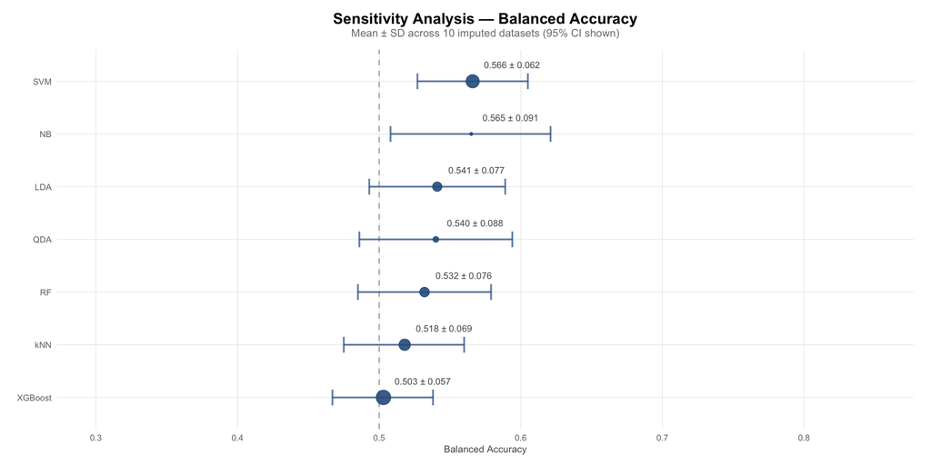

### 3.3 Feature Selection Stability

The divergence between classifiers on REAL, with some favouring the lipid oxidation region and others the ester region, reflects genuine methodological uncertainty rather than noise, and indicates that the discriminative NIR signal for freshness in Sparus aurata is distributed across multiple spectral regions rather than concentrated at a single wavelength.

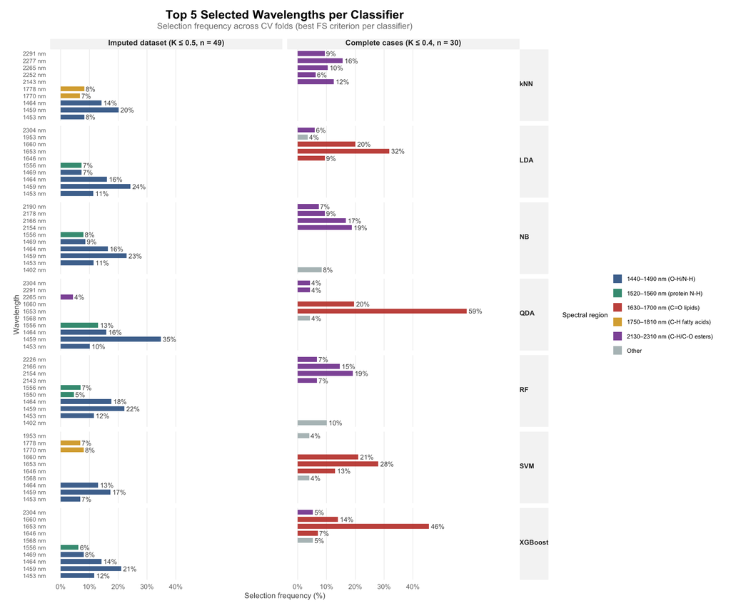

### 3.4 Permutation Tests

To assess whether classification performance exceeded chance, permutation tests (999 permutations) were conducted on the best-performing classifier per dataset. On the imputed dataset, RF_anova achieved a balanced accuracy of 0.560, compared to a mean permuted distribution of 0.487 (p = 0.188, see left panel). The observed performance does not significantly exceed the null distribution, indicating that the discriminative signal of NIR spectra on the imputed dataset cannot be distinguished from chance through the cross-validation scheme. On the complete-case dataset, NB_mrmr achieved a balanced accuracy of 0.667, compared to a mean permuted distribution of 0.495 (p = 0.040, see right panel). This result is statistically significant, indicating that NIR spectra carry genuine discriminative information for freshness classification on the complete-case data beyond what would be expected by chance.

The contrast between the two datasets is informative: the absence of significance on IMP despite higher sample size (n = 49) compared to REAL (n = 30) suggests that the imputation process introduces variability that dilutes the discriminative NIR signal, rather than amplifying it. This reinforces the interpretation that results on complete-case data represent a more reliable, even though more conservative, estimate of the true discriminative capacity of NIR spectroscopy for Sparus aurata freshness classification.

Table 8: Permutation analysis

| model | obs_bacc | perm_mean | p_value | result |
| --- | --- | --- | --- | --- |
| RF_anova | 0.560 | 0.487 | 0.188 | not significant |
| NB_mrmr | 0.667 | 0.495 | 0.040 | significant |

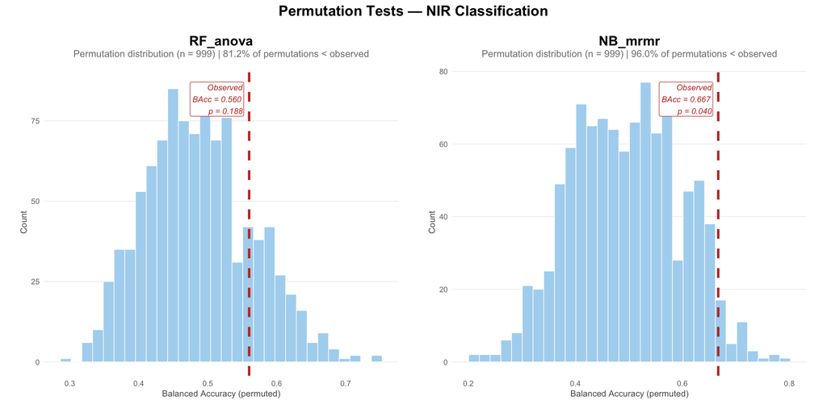

## **Linear Mixed Model Analysis**

### 4.2 LMM Candidate Comparison

#### 4.3 Final Model

The final LMM was fitted by REML with NIR_1520_1532 as fixed effect and storage day as random intercept:

$$\text{Kvalue}_{ij} = (\beta_0 + u_j) +
\beta_1 \cdot \text{NIR}_{1520\text{-}1532,ij} +
\varepsilon_{ij}$$

$$u_j \sim \mathcal{N}(0,
\sigma^2_{\text{day}}), \quad \varepsilon_{ij} \sim \mathcal{N}(0,
\sigma^2)$$

Table 9: Partial correlations

| banda | r_simple | r_partial | p_partial | abs_r |
| --- | --- | --- | --- | --- |
| W1526 | -0.094 | 0.364 | 0.052 | 0.364 |
| W1520 | -0.111 | 0.333 | 0.078 | 0.333 |
| W1532 | -0.104 | 0.328 | 0.083 | 0.328 |
| W1453 | -0.088 | 0.302 | 0.112 | 0.302 |
| W1448 | -0.015 | 0.299 | 0.115 | 0.299 |
| W1459 | -0.137 | 0.282 | 0.139 | 0.282 |
| W1443 | 0.026 | 0.279 | 0.142 | 0.279 |
| W1538 | -0.135 | 0.270 | 0.157 | 0.270 |
| W1364 | -0.029 | -0.270 | 0.157 | 0.270 |
| W1359 | -0.059 | -0.269 | 0.158 | 0.269 |
| W1464 | -0.133 | 0.268 | 0.159 | 0.268 |
| W1368 | -0.001 | -0.261 | 0.171 | 0.261 |
| W1514 | -0.145 | 0.258 | 0.177 | 0.258 |
| W1354 | -0.090 | -0.256 | 0.179 | 0.256 |
| W1469 | -0.106 | 0.251 | 0.190 | 0.251 |

Table 10: Model results

| predictor | beta | p_fixed | p_LRT | R2_marginal | delta_R2 | AIC |
| --- | --- | --- | --- | --- | --- | --- |
| Mean 1520-1532 nm (significant partial correlation) | 0.2162 | 0.0125 | 0.0176 | 0.0275 | 0.0555 | -101.93 |
| O-H/N-H | 0.0503 | 0.2651 | 0.2675 | 0.0071 | 0.0155 | -97.53 |
| C-H/C-O esters | -0.2381 | 0.4851 | 0.5187 | 0.0045 | 0.0180 | -96.71 |
| C-H fatty acids | -0.1022 | 0.5513 | 0.5469 | 0.0024 | -0.0023 | -96.66 |
| C=O lipids | -0.0243 | 0.7409 | 0.7408 | 0.0008 | -0.0032 | -96.41 |

The NIR 1520-1532 nm region was significantly associated with K-value ($\beta$ = 0.218, SE = 0.081, $t$ = 2.689, df = 19.69, $p$ = 0.014), explaining an additional 6% of K-value variance beyond the temporal trend ($\Delta R^2$ = 0.06). Between-day variability accounted for the large majority of total variance ($\sigma^2_{\text{day}}$ = 0.0066, $\sigma^2_{\text{residual}}$ = 0.0005, ICC = 0.93), confirming the dominant role of storage day in determining freshness.

A random slope for NIR_1520_1532 was also tested but did not improve model fit (LRT: $\chi^2$ = 0.727, df = 2, $p$ = 0.695), indicating that the association between NIR absorbance and K-value is consistent across storage days.